# Alien plant species

[NO_ALIE_002]

Authors

Affiliation

Joachim Töpper

Norwegian Institute for Nature Research

Matthew Grainger

Norwegian Institute for Nature Research

Published

July 1, 2026

Reviewed by

Matthew Grainger; Anders Kolstad

> **Recommended citation**: Töpper, J. & Grainger, M.J 2026. Alien plant species (ID(s): NO_ALIE_002) v. 1.0.0. ecRxiv: https://github.com/NINAnor/ecRxiv/tree/main/indicators/NO_ALIE_002

**Metadata**

Table 1: Indicator metadata

| Variable | Value |
| --- | --- |
| Indicator ID | NO_ALIE_002 |
| Indicator Name | Alien plant species |
| verbatimName | Fremmede plantearter |
| Country | Norway |
| Continent | Europe |
| Ecosystem Condition Typology Class | B1 - Biotic compositional characteristics |
| Realm | Terrestrial (T) |
| Biome | T6 Polar-alpine (cryogenic) biome |
| Ecosystem | T6.5 Trop alpine grassland; T6.3 Polar tundra |
| verbatimEcosystem | Fjell |
| Year added | 2025 |
| Last update | 2026 |
| Version | 1.0.0 |
| Version comment | separate code for mountain ecosystem. Revised reference values. Previous version was 000.002 |
| Normalised | TRUE |
| Spatial aggregation pathway | Scale/Truncate - Aggregate (site-level arithmetic mean; cluster bootstrap) |
| Precision | 95% confidence intervals estimated using a stratified cluster bootstrap of ANO sites. |

**Log**

- 21 May 2026 - original start-up of the 2026 alien species indicator for mountains
- June 31 2026 - Accepted
- 11 August 2026 - Minor update to metadata

## 1. Summary

1. **Background and rationale**: Alien plant species have a profound impact on native species and ecosystem dynamics and thus affect ecosystem condition significantly. This indicator describes how abundant alien plant species are in an ecosystem. The main anthropogenic factors behind increasing alien plant species abundance are i) introduction of alien plant species, and ii) climate change. See Framstad et al. (2022) for previous implementations of this indicator.
2. **Methods**: The indicator uses ANO monitoring data on alien plant species cover, originally recorded on a scale from 0-100% cover. The definition of an alien plant species are species introduced by humans and which we not established in Norway before year 1800. The reference values for scaling the original cover values to a condition index are as follows: <sub>x</sub>100 (best possible condition) is set to 0% alien plant species cover and scales to an indicator value of 1, and; <sub>x</sub>0 (lowest possible condition) is set to 50% and higher alien species cover and scales to an indicator value of 0. These reference values are expert-judgement based. The x0-values of >=50% follows the rationale in NiN for a natural ecosystem turning into a ‘clearly altered system’ when alien plant species dominate the vegetation. We do not specify a x60 due to lack of empirical evidence at which cover x60 should lie. In practice, this though means that a cover of 20% scales to 0.6 and thus represents x60.
3. **Interpretation**: An indicator value of 1 represents perfect condition as it signifies abscence of alien plant species. An indicator value of 0.6 represents the lowest indicator values still interpretable as ‘good condition’. Values decreasing from 0.6 toward zero represent increasing degrees of condition degradation. A value of 0 signifies that the ecosystem has changed into another altered system due to dominance of alien plant species.
4. **Results and development needs**: The indicator is well developed and argued, and is thus operational. Potential improvements to the indicator could be including non-linear scaling functions instead of the pointwise linear scaling between the reference values.

## 2. About the underlying data

Here, we evaluate the ’Alien plant species’indicator based on field sampled plant community data from the Norwegian nature monitoring program ANO (Tingstad et al. 2019).

### 2.1 Spatial and temporal resolution and extent

The ANO monitoring data available now represent one cycle of sampling from 2019-2024 comprising ca. 1000 sites across Norway. ANO has no defined end date. 2025 is the first year of repeated sampling for about 20% of the approximately 1000 ANO sites for all of mainland Norway (i.e. the Ecosystem Accounting Area). Annual sampling is spatially representative, in principle allowing to compute area-representative estimates for single years but also multiple-yr-reporting periods. The indicator at hand is calculated based on the ANO data from 2020-2024.

### 2.2 Sampling design

At every ANO site, the indicator variable is registered at up to 18 monitoring points, dependent on the ecosystem designation.

### 2.3 Original units

Abundance data for alien plant species in ANO is given as % cover within a 250 m<sup>2</sup> sample circle following the national alien species list (Artsdatabanken 2023).

### 2.4 Instructions for citing, using and accessing data

The ANO data are openly available from [Miljodirektoratet](https://kartkatalog.miljodirektoratet.no/Dataset/Details/2054).

### 2.5 Additional comments about the dataset

The ANO program is run by the Norwegian Environment Agency. On their [web site](https://www.miljodirektoratet.no/ansvarsomrader/overvaking-arealplanlegging/miljoovervaking/overvakingsprogrammer/natur-pa-land/arealrepresentativ-naturovervakning-ano/) you may also find some additional summary data.

## 3. Indicator properties

### 3.1 Ecosystem Condition Typology Class (ECT)

The ‘Alien plant species’ indicator reflects the plant species composition and thus represents ECT class ‘B1 Biotic compositional characteristics’.

### 3.2 Ecosystem condition characteristic

Intact native vegetation

### 3.3 Collinearities with other indicators

None.

### 3.4 Impact factors

The main impact factor for this indicator is the introduction of alien species. In addition, the spreading of introduced alien species can be enforced by climate change if it relaxes climatic limitation on them.

### 3.5 Spatial aggregation

The variable is scaled at the ANO-point level and aggregated by calculating the arithmetic mean across monitoring points. Confidence intervals are estimated using a stratified cluster bootstrap at the ANO-site level to account for the clustered sampling design.

## 4. Reference condition and levels

### 4.1 Reference condition

In Norway, the reference condition for natural ecosystems has been one of largely intact ecosystems without large-scale human modifications (Nybø and Evju 2017). For semi-natural ecosystems, human influence is allowed, and indeed a prerequisite, but then in the sense of appropriate, stable and traditional land-use practices. Thus, in terms of alien species, the reference condition is defined as an ecosystem without any alien plant species.

### 4.2 Reference levels

X<sub>100</sub>: 0% alien plant species cover

X<sub>0</sub>: 50% or more alien plant species cover

#### 4.2.1 Spatial resolution and validity

The same reference levels apply to all types of ecosystems and all regions.

## 5. Uncertainties

### 5.1 General uncertainties

Uncertainties relate partly to sampling and observer variability (and possible observer bias) in the recording of the plant cover data. Spatial variability as a source of descriptive uncertainty can be quantified.

### 5.2 Reported uncertainties

For this indicator, we report 95% confidence intervals estimated using a stratified cluster bootstrap of ANO sites. Sites are resampled with replacement within each region while retaining all monitoring points belonging to each selected site. This accounts for the clustered sampling design of the ANO programme without making assumptions about the distribution of indicator values.

## 6. References

Artsdatabanken (2023, 11. august). Fremmede arter i Norge - med økologisk risiko 2023. http://www.artsdatabanken.no/lister/fremmedartslista/2023.

Framstad, E., Kolstad, A. L., Nybø, S., Töpper, J. & Vandvik, V. 2022. The condition of forest and mountain ecosystems in Norway. Assessment by the IBECA method. NINA Report 2100. Norwegian Institute for Nature Research.

Nybø, S. & Evju, M. (red.) 2017. Fagsystem for fastsetting av god økologisk tilstand. Forslag fra et ekspertråd, https://regjeringen.no/no/dokument/rapportar-og-planar/id438817/.

Tingstad, L., Evju, M., Sickel, H., & Töpper, J. 2019. Utvikling av nasjonal arealrepresentativ naturovervåking (ANO). Forslag til gjennomføring, protokoller og kostnadsvurderinger med utgangspunkt i erfaringer fra uttesting i Trøndelag. NINA Rapport 1642.

## 7. Import and prepare datasets

### 7.1 ANO point data

Import ANO testing data: First, download from [Miljødirektoratet](https://kartkatalog.miljodirektoratet.no/Dataset/Details/2054)and then upload from local storage.

The geodatabase contains several layers; ‘ANO_SurveyPoint’ contains site and point data including alien plant species cover.

```r
#Sys.setlocale("LC_ALL", "no_NB.utf8") #works with æøå or use "Norwegian"
ANO.geo <- st_read("P:/41201785_okologisk_tilstand_2022_2023/data/ANO/naturovervaking_eksport.gdb",
                   layer="ANO_SurveyPoint", quiet = T)
#head(ANO.geo)
```

## 8. Spatial units

The spatial units for the ‘Alien plant species’ indicator are governed by the ANO data, which consist of 1000 randomly chosen sites in Norway. Each site is a 500 x 500 m grid cell with 18 monitoring circles of 250sqm and a central 1 x 1 m vegetation plot. The basic unit for which observational alien plant species abundance data exist, and for which every the ‘Alien plant species’ indicator is computed, is the 250sqm circle. Aggregation of these basic spatial units to higher ones - like sites, municipalities, counties, regions, or the national level - should be done with appropriate consideration of the spatial structure of the data, i.e. imbalances and clustering (highly unequal number of points of an ecosystem type between sites).

## 9. Analyses

#### Data handling

First we need to do some data handling. The data for this evaluation need to represent mountain ecosystems and the years 2020-2024.

```r
## choose mountain ecosystems and years 2020-2024.
ANO.mount <- ANO.geo %>%
  filter(hovedoekosystem_250m2 == 'fjell') %>%
  filter(aar %in% 2020:2024)

#head(ANO.mount)

## check that every point is present only once
#length(levels(as.factor(ANO.mount$ano_flate_id)))
#length(levels(as.factor(ANO.mount$ano_punkt_id)))
#summary(as.factor(ANO.mount$ano_punkt_id))
# there's many double presences, probably some wrong registrations of point numbers,

## add region information
nor <- st_read(here::here("data/outlineOfNorway_EPSG25833.shp"),
               quiet = T)%>%
  st_as_sf() %>%
  st_transform(crs = st_crs(ANO.mount))

reg <- st_read(here::here("data/regions.shp"),
               quiet = T) %>%
  st_as_sf() %>%
  st_transform(crs = st_crs(ANO.mount))

# change region names to something R-friendly
# reg$region
reg$region <- c("Northern.Norway","Central.Norway","Eastern.Norway","Western.Norway","Southern.Norway")

regnor <- st_intersection(reg,nor)

ANO.mount <- st_join(ANO.mount, regnor, left = TRUE, join = st_nearest_feature)
```

We can illustrate the cover of alien plant species in ANO points in Norway’s five regions in a figure

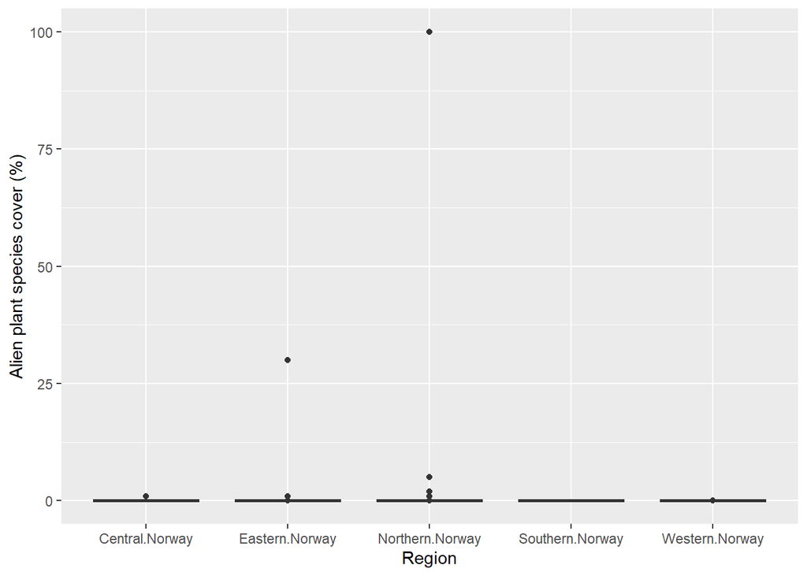

```r
ggplot(ANO.mount, aes(x = region, y = fremmedarter_total_dekning)) +
  geom_boxplot() +
  labs(
    x = "Region",
    y = "Alien plant species cover (%)"
    )
```

#### Normalisation

We use a normalisation function scaling linearly between the reference values. The function is demonstrated in the code below, and in Figure 1.

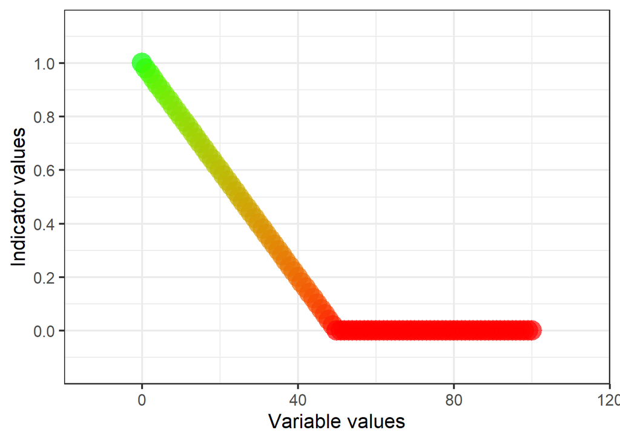

Figure 1: Normalisation function

```r
temp <- tibble(
  variable = 0:100
)

temp <- temp %>% mutate(indicator = ec_normalise(variable = variable,
                          x0 = 50,
                          #x60 = 5,
                          x100 = 0,
                          fun = "linear")
)

ec_norm_plot(variable = temp$variable, indicator = temp$indicator)
```

We scale the variable values to indicator values using ec_normalise() from ecTools.

```r
ANO.mount <- ANO.mount %>% mutate(alien_res = ec_normalise(variable = fremmedarter_total_dekning,
                          x0 = 50,
                          #x60 = 5,
                          x100 = 0,
                          fun = "linear")
)

summary(ANO.mount$alien_res)
```

[output not shown]

#### Calculating national and regional indices

Indicator values are calculated as the arithmetic mean of the normalised indicator values across ANO monitoring points. Because multiple monitoring points are sampled within each ANO site, observations within a site are not independent. To account for this clustered sampling design, uncertainty is estimated using a stratified cluster bootstrap. For each bootstrap replicate, ANO sites are sampled with replacement independently within each region while retaining all monitoring points belonging to each selected site. Regional indicator values are recalculated for each replicate, and the national value is calculated from the combined bootstrap sample. The distribution of bootstrap estimates is used to derive 95% confidence intervals.

## 10. Results

Indicator values are calculated as arithmetic means of the normalised indicator values. To quantify uncertainty, we perform a stratified cluster bootstrap with 1,000 replicates. Within each replicate, ANO sites are resampled with replacement within each region while retaining all monitoring points from each selected site. The distribution of bootstrap estimates is used to calculate the mean indicator value and the associated 95% confidence interval.

```r
set.seed(123)

B <- 1000

dat <- ANO.mount |>
  st_drop_geometry() |>
  filter(!is.na(alien_res), !is.na(region))

boot_results <- map_dfr(1:B, function(i) {

  boot_dat <- dat |>
    group_by(region) |>
    group_modify(~ {

      sites <- unique(.x$ano_flate_id)

      sampled_sites <- sample(
        sites,
        size = length(sites),
        replace = TRUE
      )

      bind_rows(
        lapply(sampled_sites, function(s) {
          filter(.x, ano_flate_id == s)
        })
      )
    }) |>
    ungroup()

  regional <- boot_dat |>
    group_by(region,ano_flate_id) |>
    summarise(alien_XXX = mean(alien_res), .group = "drop") |>
    group_by(region) |>
    summarise(
      sim = mean(alien_XXX, na.rm = TRUE),
      .groups = "drop"
    ) |>
    rename(Region = region)

  national <- tibble(
    Region = "Norway",
    sim = mean(boot_dat$alien_res, na.rm = TRUE)
  )

  bind_rows(national, regional) |>
    mutate(draw = i)
})

NO_ALIE_002_table <- boot_results |>
  group_by(Region) |>
  summarise(
    indicator_value = mean(sim, na.rm = TRUE),
    CI_lower = quantile(sim, 0.025, na.rm = TRUE),
    CI_upper = quantile(sim, 0.975, na.rm = TRUE),
    .groups = "drop"
  ) |>
  mutate(Year = 2024)
NO_ALIE_002_table
saveRDS(NO_ALIE_002_table, here::here("data/ANO_ALIE_002_table.rds"))
```

[output not shown]

## 11. Export file

```r
# write to parquet using arrow
NO_ALIE_002_sim <- boot_results |>
  mutate(year = 2024)

arrow::write_parquet(
  NO_ALIE_002_sim,
  "data/results_NO_ALIE_002_sim.parquet"
)
```

## 12. Author contributions

**CRediT statement**

- Conceptualization: [JT]
- Methodology: [JT, MG]
- Data curation: [JT, MG]
- Formal analysis: [JT, MG]
- Visualization: [JT]
- Reproducibility: [JT, MG]

**Session Info**

This workflow uses `renv`. Run `renv::restore()` to get started.